# IEU GWAS QC Report

## IEU GWAS information

Trait: **Current tobacco smoking**.

| name | value |
| --- | --- |
| id | UKB-b-223 |
| trait | Current tobacco smoking |
| note | 1239: Output from GWAS pipeline using Phesant derived variables from UKBiobank |
| year | 2018 |
| author | Ben Elsworth |
| population | European |
| sex | Males and Females |
| sample_size | 462434 |
| units | SD |
| build | HG19/GRCh37 |
| group_name | public |
| access | public |
| nsnp | 9851867 |
| mr | 1 |
| category | Categorical Ordered |
| batch | UKB-b |
| sd | NULL |
| priority | 1 |
| consortium | MRC-IEU |

## Report information

| name | value |
| --- | --- |
| gwas_id | ukb-b-223 |
| bcf_file | ukb-b-223.vcf.gz |
| qc_metrics_file | qc_metrics.json |
| metadata | metadata.json |
| refdata | 1kg_v3_nomult.bcf |
| compile_time | 2020-05-10 13:26 BST |
| build_version | run_igd-8f4f4c9-2020-05-09 |

# Summary

## Summary {data-width=650}

### Manhattan plot

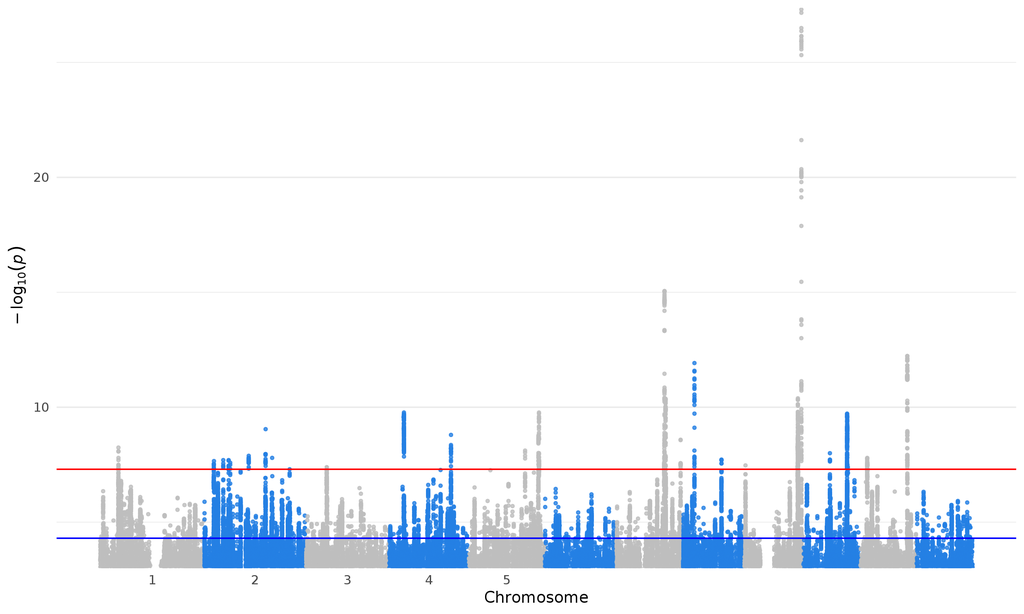

manhattan_plot

### QQ plot

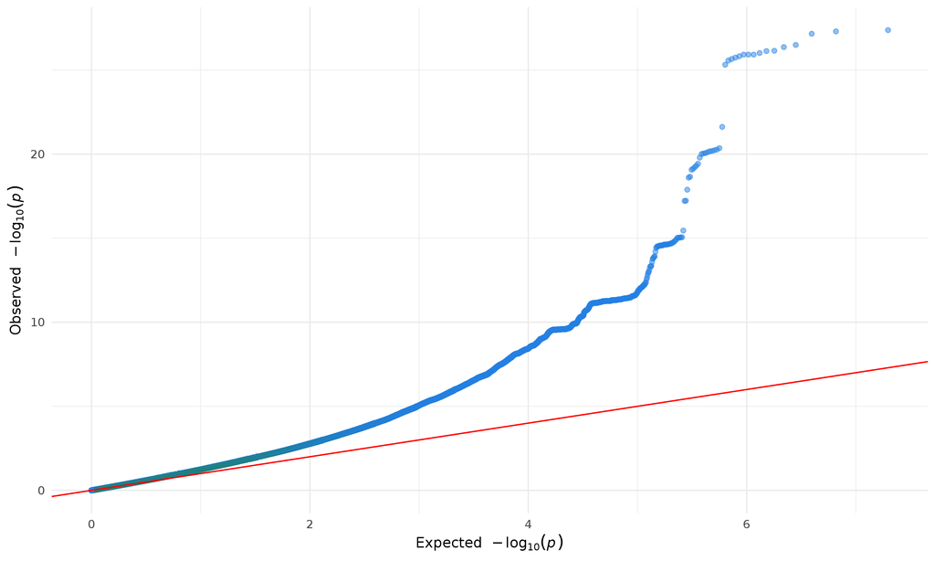

qq_plot

### AF plot

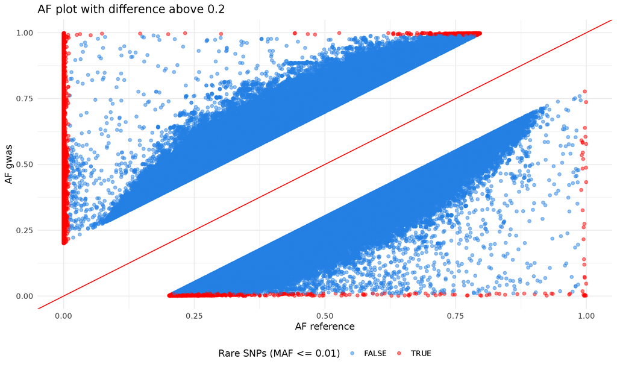

af_plot

### P-Z plot

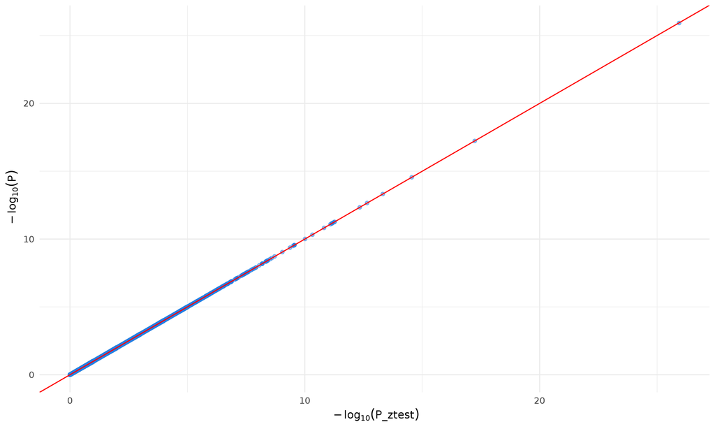

pz_plot

### beta_std plot

[figure not shown]

beta_std_plot

### Metadata

```
{
    "fileformat": "VCFv4.2",
    "FILTER": "<ID=PASS,Description=\"All filters passed\">",
    "INFO": "<ID=AF,Number=A,Type=Float,Description=\"Allele Frequency\">",
    "FORMAT": "<ID=ES,Number=A,Type=Float,Description=\"Effect size estimate relative to the alternative allele\">",
    "FORMAT.1": "<ID=SE,Number=A,Type=Float,Description=\"Standard error of effect size estimate\">",
    "FORMAT.2": "<ID=LP,Number=A,Type=Float,Description=\"-log10 p-value for effect estimate\">",
    "FORMAT.3": "<ID=AF,Number=A,Type=Float,Description=\"Alternate allele frequency in the association study\">",
    "FORMAT.4": "<ID=SS,Number=A,Type=Float,Description=\"Sample size used to estimate genetic effect\">",
    "FORMAT.5": "<ID=EZ,Number=A,Type=Float,Description=\"Z-score provided if it was used to derive the EFFECT and SE fields\">",
    "FORMAT.6": "<ID=SI,Number=A,Type=Float,Description=\"Accuracy score of summary data imputation\">",
    "FORMAT.7": "<ID=NC,Number=A,Type=Float,Description=\"Number of cases used to estimate genetic effect\">",
    "FORMAT.8": "<ID=ID,Number=1,Type=String,Description=\"Study variant identifier\">",
    "META": "<ID=TotalVariants,Number=1,Type=Integer,Description=\"Total number of variants in input\">",
    "META.1": "<ID=VariantsNotRead,Number=1,Type=Integer,Description=\"Number of variants that could not be read\">",
    "META.2": "<ID=HarmonisedVariants,Number=1,Type=Integer,Description=\"Total number of harmonised variants\">",
    "META.3": "<ID=VariantsNotHarmonised,Number=1,Type=Integer,Description=\"Total number of variants that could not be harmonised\">",
    "META.4": "<ID=SwitchedAlleles,Number=1,Type=Integer,Description=\"Total number of variants strand switched\">",
    "META.5": "<ID=TotalControls,Number=1,Type=Integer,Description=\"Total number of controls in the association study\">",
    "META.6": "<ID=TotalCases,Number=1,Type=Integer,Description=\"Total number of cases in the association study\">",
    "META.7": "<ID=StudyType,Number=1,Type=String,Description=\"Type of GWAS study [Continuous or CaseControl]\">",
    "SAMPLE": "<ID=UKB-b:223,TotalVariants=9851866,VariantsNotRead=0,HarmonisedVariants=9851866,VariantsNotHarmonised=0,SwitchedAlleles=9851866,TotalControls=462434,StudyType=Continuous>",
    "contig": "<ID=1,length=249250621,assembly=GRCh37>",
    "contig.1": "<ID=2,length=243199373,assembly=GRCh37>",
    "contig.2": "<ID=3,length=198022430,assembly=GRCh37>",
    "contig.3": "<ID=4,length=191154276,assembly=GRCh37>",
    "contig.4": "<ID=5,length=180915260,assembly=GRCh37>",
    "contig.5": "<ID=6,length=171115067,assembly=GRCh37>",
    "contig.6": "<ID=7,length=159138663,assembly=GRCh37>",
    "contig.7": "<ID=8,length=146364022,assembly=GRCh37>",
    "contig.8": "<ID=9,length=141213431,assembly=GRCh37>",
    "contig.9": "<ID=10,length=135534747,assembly=GRCh37>",
    "contig.10": "<ID=11,length=135006516,assembly=GRCh37>",
    "contig.11": "<ID=12,length=133851895,assembly=GRCh37>",
    "contig.12": "<ID=13,length=115169878,assembly=GRCh37>",
    "contig.13": "<ID=14,length=107349540,assembly=GRCh37>",
    "contig.14": "<ID=15,length=102531392,assembly=GRCh37>",
    "contig.15": "<ID=16,length=90354753,assembly=GRCh37>",
    "contig.16": "<ID=17,length=81195210,assembly=GRCh37>",
    "contig.17": "<ID=18,length=78077248,assembly=GRCh37>",
    "contig.18": "<ID=19,length=59128983,assembly=GRCh37>",
    "contig.19": "<ID=20,length=63025520,assembly=GRCh37>",
    "contig.20": "<ID=21,length=48129895,assembly=GRCh37>",
    "contig.21": "<ID=22,length=51304566,assembly=GRCh37>",
    "contig.22": "<ID=X,length=155270560,assembly=GRCh37>",
    "contig.23": "<ID=Y,length=59373566,assembly=GRCh37>",
    "contig.24": "<ID=MT,length=16569,assembly=GRCh37>",
    "contig.25": "<ID=GL000207.1,length=4262,assembly=GRCh37>",
    "contig.26": "<ID=GL000226.1,length=15008,assembly=GRCh37>",
    "contig.27": "<ID=GL000229.1,length=19913,assembly=GRCh37>",
    "contig.28": "<ID=GL000231.1,length=27386,assembly=GRCh37>",
    "contig.29": "<ID=GL000210.1,length=27682,assembly=GRCh37>",
    "contig.30": "<ID=GL000239.1,length=33824,assembly=GRCh37>",
    "contig.31": "<ID=GL000235.1,length=34474,assembly=GRCh37>",
    "contig.32": "<ID=GL000201.1,length=36148,assembly=GRCh37>",
    "contig.33": "<ID=GL000247.1,length=36422,assembly=GRCh37>",
    "contig.34": "<ID=GL000245.1,length=36651,assembly=GRCh37>",
    "contig.35": "<ID=GL000197.1,length=37175,assembly=GRCh37>",
    "contig.36": "<ID=GL000203.1,length=37498,assembly=GRCh37>",
    "contig.37": "<ID=GL000246.1,length=38154,assembly=GRCh37>",
    "contig.38": "<ID=GL000249.1,length=38502,assembly=GRCh37>",
    "contig.39": "<ID=GL000196.1,length=38914,assembly=GRCh37>",
    "contig.40": "<ID=GL000248.1,length=39786,assembly=GRCh37>",
    "contig.41": "<ID=GL000244.1,length=39929,assembly=GRCh37>",
    "contig.42": "<ID=GL000238.1,length=39939,assembly=GRCh37>",
    "contig.43": "<ID=GL000202.1,length=40103,assembly=GRCh37>",
    "contig.44": "<ID=GL000234.1,length=40531,assembly=GRCh37>",
    "contig.45": "<ID=GL000232.1,length=40652,assembly=GRCh37>",
    "contig.46": "<ID=GL000206.1,length=41001,assembly=GRCh37>",
    "contig.47": "<ID=GL000240.1,length=41933,assembly=GRCh37>",
    "contig.48": "<ID=GL000236.1,length=41934,assembly=GRCh37>",
    "contig.49": "<ID=GL000241.1,length=42152,assembly=GRCh37>",
    "contig.50": "<ID=GL000243.1,length=43341,assembly=GRCh37>",
    "contig.51": "<ID=GL000242.1,length=43523,assembly=GRCh37>",
    "contig.52": "<ID=GL000230.1,length=43691,assembly=GRCh37>",
    "contig.53": "<ID=GL000237.1,length=45867,assembly=GRCh37>",
    "contig.54": "<ID=GL000233.1,length=45941,assembly=GRCh37>",
    "contig.55": "<ID=GL000204.1,length=81310,assembly=GRCh37>",
    "contig.56": "<ID=GL000198.1,length=90085,assembly=GRCh37>",
    "contig.57": "<ID=GL000208.1,length=92689,assembly=GRCh37>",
    "contig.58": "<ID=GL000191.1,length=106433,assembly=GRCh37>",
    "contig.59": "<ID=GL000227.1,length=128374,assembly=GRCh37>",
    "contig.60": "<ID=GL000228.1,length=129120,assembly=GRCh37>",
    "contig.61": "<ID=GL000214.1,length=137718,assembly=GRCh37>",
    "contig.62": "<ID=GL000221.1,length=155397,assembly=GRCh37>",
    "contig.63": "<ID=GL000209.1,length=159169,assembly=GRCh37>",
    "contig.64": "<ID=GL000218.1,length=161147,assembly=GRCh37>",
    "contig.65": "<ID=GL000220.1,length=161802,assembly=GRCh37>",
    "contig.66": "<ID=GL000213.1,length=164239,assembly=GRCh37>",
    "contig.67": "<ID=GL000211.1,length=166566,assembly=GRCh37>",
    "contig.68": "<ID=GL000199.1,length=169874,assembly=GRCh37>",
    "contig.69": "<ID=GL000217.1,length=172149,assembly=GRCh37>",
    "contig.70": "<ID=GL000216.1,length=172294,assembly=GRCh37>",
    "contig.71": "<ID=GL000215.1,length=172545,assembly=GRCh37>",
    "contig.72": "<ID=GL000205.1,length=174588,assembly=GRCh37>",
    "contig.73": "<ID=GL000219.1,length=179198,assembly=GRCh37>",
    "contig.74": "<ID=GL000224.1,length=179693,assembly=GRCh37>",
    "contig.75": "<ID=GL000223.1,length=180455,assembly=GRCh37>",
    "contig.76": "<ID=GL000195.1,length=182896,assembly=GRCh37>",
    "contig.77": "<ID=GL000212.1,length=186858,assembly=GRCh37>",
    "contig.78": "<ID=GL000222.1,length=186861,assembly=GRCh37>",
    "contig.79": "<ID=GL000200.1,length=187035,assembly=GRCh37>",
    "contig.80": "<ID=GL000193.1,length=189789,assembly=GRCh37>",
    "contig.81": "<ID=GL000194.1,length=191469,assembly=GRCh37>",
    "contig.82": "<ID=GL000225.1,length=211173,assembly=GRCh37>",
    "contig.83": "<ID=GL000192.1,length=547496,assembly=GRCh37>",
    "gwas_harmonisation_command": "--out /mnt/storage/private/mrcieu/research/scratch/IGD/data/public/ukbiobank/vcf_09_19b/bgzip_vcf/data.batch_1239.vcf.gz --id UKB-b:223 --data /mnt/storage/private/mrcieu/research/scratch/IGD/data/public/ukbiobank/raw-output/data.batch_1239.txt.gz --cohort_controls 462434 --ref /mnt/storage/private/mrcieu/research/scratch/IGD/data/public/ukbiobank/human_g1k_v37.fasta --json /mnt/storage/private/mrcieu/research/scratch/IGD/data/public/ukbiobank/ukb_gwas.json; 1.1.1",
    "file_date": "2019-09-13T13:39:44.373986",
    "bcftools_viewVersion": "1.9-74-g6af271c+htslib-1.9-64-g226b4a8",
    "bcftools_viewCommand": "view -h /mnt/storage/private/mrcieu/research/scratch/IGD/data/public/ukb-b-223/ukb-b-223.vcf.gz; Date=Sun May 10 13:16:41 2020"
}
```

### LDSC

```
*********************************************************************
* LD Score Regression (LDSC)
* Version 1.0.1
* (C) 2014-2019 Brendan Bulik-Sullivan and Hilary Finucane
* Broad Institute of MIT and Harvard / MIT Department of Mathematics
* GNU General Public License v3
*********************************************************************
Call:
./ldsc.py \
--h2 /mnt/storage/private/mrcieu/research/scratch/IGD/data/public/UKB-b-223/UKB-b-223_data.vcf.gz \
--ref-ld-chr ../reference/eur_w_ld_chr/ \
--out /mnt/storage/private/mrcieu/research/scratch/IGD/data/public/UKB-b-223/ldsc.txt \
--w-ld-chr ../reference/eur_w_ld_chr/

Beginning analysis at Thu Oct 17 14:42:22 2019
Reading summary statistics from /mnt/storage/private/mrcieu/research/scratch/IGD/data/public/UKB-b-223/UKB-b-223_data.vcf.gz ...
Read summary statistics for 9851866 SNPs.
Dropped 14738 SNPs with duplicated rs numbers.
Reading reference panel LD Score from ../reference/eur_w_ld_chr/[1-22] ...
Read reference panel LD Scores for 1290028 SNPs.
Removing partitioned LD Scores with zero variance.
Reading regression weight LD Score from ../reference/eur_w_ld_chr/[1-22] ...
Read regression weight LD Scores for 1290028 SNPs.
After merging with reference panel LD, 1289166 SNPs remain.
After merging with regression SNP LD, 1289166 SNPs remain.
Using two-step estimator with cutoff at 30.
Total Observed scale h2: 0.0525 (0.0023)
Lambda GC: 1.4149
Mean Chi^2: 1.5198
Intercept: 1.0419 (0.0082)
Ratio: 0.0806 (0.0158)
Analysis finished at Thu Oct 17 14:44:04 2019
Total time elapsed: 1.0m:42.21s
```

# QC metrics

## Metrics

### Metrics

```
{
    "af_correlation": 0.9499,
    "inflation_factor": 1.3107,
    "mean_EFFECT": 0.0001,
    "n": "-Inf",
    "n_snps": 9851866,
    "n_clumped_hits": 35,
    "n_p_sig": 1958,
    "n_mono": 0,
    "n_ns": 0,
    "n_mac": 0,
    "is_snpid_unique": true,
    "n_miss_EFFECT": 0,
    "n_miss_SE": 0,
    "n_miss_PVAL": 0,
    "n_miss_AF": 0,
    "n_miss_AF_reference": 184849,
    "n_est": "NA",
    "ratio_se_n": "NA",
    "mean_diff": "NaN",
    "ratio_diff": "NaN",
    "sd_y_est1": "NaN",
    "sd_y_est2": "NA",
    "r2_sum1": 0,
    "r2_sum2": 0,
    "r2_sum3": 0,
    "r2_sum4": 0,
    "ldsc_nsnp_merge_refpanel_ld": 1289166,
    "ldsc_nsnp_merge_regression_ld": 1289166,
    "ldsc_observed_scale_h2_beta": 0.0525,
    "ldsc_observed_scale_h2_se": 0.0023,
    "ldsc_intercept_beta": 1.0419,
    "ldsc_intercept_se": 0.0082,
    "ldsc_lambda_gc": 1.4149,
    "ldsc_mean_chisq": 1.5198,
    "ldsc_ratio": 0.0806
}
```

### Flags

| name | value |
| --- | --- |
| af_correlation | FALSE |
| inflation_factor | TRUE |
| n | TRUE |
| is_snpid_non_unique | FALSE |
| mean_EFFECT_nonfinite | FALSE |
| mean_EFFECT_05 | FALSE |
| mean_EFFECT_01 | FALSE |
| mean_chisq | TRUE |
| n_p_sig | TRUE |
| miss_EFFECT | FALSE |
| miss_SE | FALSE |
| miss_PVAL | FALSE |
| ldsc_ratio | FALSE |
| ldsc_intercept_beta | FALSE |
| n_clumped_hits | FALSE |
| r2_sum1 | FALSE |
| r2_sum2 | FALSE |
| r2_sum3 | FALSE |
| r2_sum4 | FALSE |

### Definitions

**General metrics**

- `af_correlation`: Correlation coefficient between `AF` and `AF_reference`.
- `inflation_factor` (`lambda`): Genomic inflation factor.
- `mean_EFFECT`: Mean of `EFFECT` size.
- `n`: Maximum value of reported sample size across all SNPs, $n$.
- `n_clumped_hits`: Number of clumped hits.
- `n_snps`: Number of SNPs
- `n_p_sig`: Number of SNPs with pvalue below `5e-8`.
- `n_mono`: Number of monomorphic (`MAF == 1` or `MAF == 0`) SNPs.
- `n_ns`: Number of SNPs with nonsense values:
  - alleles other than `A, C, G or T`.
  - P-values `< 0` or `> 1`.
  - negative or infinite standard errors (`<= 0` or `= Infinity`).
  - infinite beta estimates or allele frequencies `< 0` or `> 1`.
- `n_mac`: Number of cases where `MAC` ($2 \times N \times MAF$) is less than `6`.
- `is_snpid_unique`: `true` if the combination of `ID` `REF` `ALT` is unique and therefore no duplication in snpid.
- `n_miss_<*>`: Number of `NA` observations for `<*>` column.

**se_n metrics**

- `n_est`: Estimated sample size value, $\widehat{n}$.
- `ratio_se_n`: $\texttt{ratio_se_n} = \frac{\sqrt{\widehat{n}}}{\sqrt{n}}$. We expect `ratio_se_n` to be 1. When it is not 1, it implies that the trait did not have a variance of 1, the reported sample size is wrong, or that the SNP-level effective sample sizes differ markedly from the reported sample size.
- `mean_diff`: $\texttt{mean_diff} = \sum_{j} \frac{\widehat{\beta_j^{std}} - \beta_j}{\texttt{n_snps}}$, mean difference between the standardised beta, predicted from P-values, and the observed beta. The difference should be very close to zero if trait has a variance of 1.
  - $\widehat{\beta_j^{std}} = \sqrt{\frac{{z}_j^2 / ({z}_j^2 + n -2)}{2 \times {MAF}_j \times (1 - {MAF}_j)}} \times sign({z}_j)$,
  - ${z}_j = \frac{\beta_j}{{se}_j}$,
  - and $\beta_j$ is the reported effect size.
- `ratio_diff`: $\texttt{ratio_diff} = |\frac{\texttt{mean_diff}}{\texttt{mean_diff2}}|$, absolute ratio between the mean of `diff` and the mean of `diff2` (expected difference between the standardised beta predicted from P-values, and the standardised beta derived from the observed beta divided by the predicted SD; **NOT** reported). The ratio should be close to 1. If different from 1, then implies that the betas are not in a standard deviation scale.
  - $\texttt{mean_diff2} = \sum_{j} \frac{\widehat{\beta_j^{std}} - \beta^{\prime}_j}{\texttt{n_snps}}$
  - $\beta^{\prime}_j = \frac{\beta_j}{\widehat{\texttt{sd2}}_{y}}$
- `sd_y_est1`: The standard deviation for the trait inferred from the reported sample size, median standard errors for the SNP-trait assocations and SNP variances.
  - $\widehat{\texttt{sd1}}_{y} = \frac{\sqrt{n} \times median({se}_j)}{C}$,
  - $C = median(\frac{1}{\sqrt{2 \times {MAF}_j \times (1 - {MAF}_j)}})$,
  - and ${se}_j$ is the reported standard error.
- `sd_y_est2`: The standard deviation for the trait inferred from the reported sample size, Z statistics for the SNP-trait effects (beta/se) and allele frequency.
  - $\widehat{\texttt{sd2}}_{y} = median(\widehat{sd_j})$,
  - $\widehat{sd_j} = \frac{\beta_j}{\widehat{\beta_j^{std}}}$,

**r2 metrics**

> Sum of variance explained, calculated from the clumped top hits sample.
- `r2_sum<*>`: `r2` statistics under various assumptions
  - `1`: $r^2 = \sum_j{\frac{2 \times \beta_j^2 \times {MAF}_j \times (1 - {MAF}_j)}{\texttt{var1}}}$, $\texttt{var1} = 1$.
  - `2`: $r^2 = \sum_j{\frac{2 \times \beta_j^2 \times {MAF}_j \times (1 - {MAF}_j)}{\texttt{var2}}}$, $\texttt{var2} = {\widehat{\texttt{sd1}}_{y}}^2$,
  - `3`: $r^2 = \sum_j{\frac{2 \times \beta_j^2 \times {MAF}_j \times (1 - {MAF}_j)}{\texttt{var3}}}$, $\texttt{var3} = {\widehat{\texttt{sd2}}_{y}}^2$,
  - `4`: $r^2 = \sum_j{\frac{F_j}{F_j + n - 2}}$, $F = \frac{\beta_j^2}{{se}_j^2}$.

**LDSC metrics**

> Metrics from LD regression
- `ldsc_nsnp_merge_refpanel_ld`: Number of remaining SNPs after merging with reference panel LD.
- `ldsc_nsnp_merge_regression_ld`: Number of remaining SNPs after merging with regression SNP LD.
- `ldsc_observed_scale_h2_{beta,se}` Coefficient value and SE for total observed scale h2.
- `ldsc_intercept_{beta,se}`: Coefficient value and SE for intercept. Intercept is expected to be 1.
- `ldsc_lambda_gc`: Lambda GC statistics.
- `ldsc_mean_chisq`: Mean $\chi^2$ statistics.
- `ldsc_ratio`: $\frac{\texttt{ldsc_intercept_beta} - 1}{\texttt{ldsc_mean_chisq} - 1}$, the proportion of the inflation in the mean $\chi^2$ that the LD Score regression intercepts ascribes to causes other than polygenic heritability. The value of ratio should be close to zero, though in practice values of 0.1-0.2 are not uncommon, probably due to sample/reference LD Score mismatch or model misspecification (e.g., low LD variants have slightly higher $h^2$ per SNP).

**Flags**

> When a metric needs attention, the flag should return TRUE.
- `af_correlation`: `abs(af_correlation)` < 0.7.
- `inflation_factor`: `inflation_factor` > 1.2.
- `n`: `n` (max reported sample size) < 10000.
- `is_snpid_non_unique`: NOT `is_snpid_unique`.
- `mean_EFFECT_nonfinite`: `mean(EFFECT)` is `NA`, `NaN`, or `Inf`.
- `mean_EFFECT_05`: `abs(mean(EFFECT))` > 0.5.
- `mean_EFFECT_01`: `abs(mean(EFFECT))` > 0.1.
- `mean_chisq`: `ldsc_mean_chisq` > 1.3 or `ldsc_mean_chisq` < 0.7.
- `n_p_sig`: `n_p_sig` > 1000.
- `miss_<*>`: `n_miss_<*>` / `n_snps` > 0.01.
- `ldsc_ratio`: `ldsc_ratio` > 0.5
- `ldsc_intercept_beta`: `ldsc_intercept_beta` > 1.5
- `n_clumped_hits`: `n_clumped_hits` > 1000
- `r2_sum<*>`: `r2_sum<*>` > 0.5

**Plots**

- Manhattan plot
  - Red line: $-log_{10}^{5 \times 10^{-8}}$
  - Blue line: $-log_{10}^{5 \times 10^{-5}}$
- QQ plot
- AF plot
- P-Z plot
- beta_std plot: Scatter plot between $\widehat{\beta_j^{std}}$ and $\beta_j$

# Diagnostics

## Details

### Summary stats

| skim_type | skim_variable | n_missing | complete_rate | character.min | character.max | character.empty | character.n_unique | character.whitespace | logical.mean | logical.count | numeric.mean | numeric.sd | numeric.p0 | numeric.p25 | numeric.p50 | numeric.p75 | numeric.p100 | numeric.hist |
| --- | --- | --- | --- | --- | --- | --- | --- | --- | --- | --- | --- | --- | --- | --- | --- | --- | --- | --- |
| character | ID | 0 | 1.0000000 | 3 | 58 | 0 | 9837196 | 0 | NA | NA | NA | NA | NA | NA | NA | NA | NA | NA |
| character | REF | 0 | 1.0000000 | 1 | 1 | 0 | 4 | 0 | NA | NA | NA | NA | NA | NA | NA | NA | NA | NA |
| character | ALT | 0 | 1.0000000 | 1 | 1 | 0 | 4 | 0 | NA | NA | NA | NA | NA | NA | NA | NA | NA | NA |
| logical | N | 9851866 | 0.0000000 | NA | NA | NA | NA | NA | NaN | : | NA | NA | NA | NA | NA | NA | NA | NA |
| numeric | CHROM | 0 | 1.0000000 | NA | NA | NA | NA | NA | NA | NA | 8.622825e+00 | 5.748290e+00 | 1.0000000 | 4.000000e+00 | 8.000000e+00 | 1.300000e+01 | 2.200000e+01 | ▇▅▃▂▂ |
| numeric | POS | 0 | 1.0000000 | NA | NA | NA | NA | NA | NA | NA | 7.886027e+07 | 5.628334e+07 | 828.0000000 | 3.259061e+07 | 6.948835e+07 | 1.145912e+08 | 2.492385e+08 | ▇▆▅▂▁ |
| numeric | EFFECT | 0 | 1.0000000 | NA | NA | NA | NA | NA | NA | NA | 1.449000e-04 | 5.753700e-03 | -0.1263790 | -1.816900e-03 | 3.270000e-05 | 1.919200e-03 | 9.165710e-02 | ▁▁▇▁▁ |
| numeric | SE | 0 | 1.0000000 | NA | NA | NA | NA | NA | NA | NA | 3.923200e-03 | 3.713400e-03 | 0.0010979 | 1.343900e-03 | 2.253500e-03 | 5.199800e-03 | 5.771210e-02 | ▇▁▁▁▁ |
| numeric | PVAL | 0 | 1.0000000 | NA | NA | NA | NA | NA | NA | NA | 4.590142e-01 | 2.995394e-01 | 0.0000000 | 1.900002e-01 | 4.400003e-01 | 7.199992e-01 | 1.000000e+00 | ▇▆▆▆▆ |
| numeric | PVAL_ztest | 0 | 1.0000000 | NA | NA | NA | NA | NA | NA | NA | 4.590141e-01 | 2.995159e-01 | 0.0000000 | 1.895974e-01 | 4.445894e-01 | 7.183560e-01 | 9.999997e-01 | ▇▆▆▆▆ |
| numeric | AF | 0 | 1.0000000 | NA | NA | NA | NA | NA | NA | NA | 2.035077e-01 | 2.568617e-01 | 0.0009940 | 1.316900e-02 | 7.791300e-02 | 3.164560e-01 | 9.990050e-01 | ▇▂▁▁▁ |
| numeric | AF_reference | 184849 | 0.9812372 | NA | NA | NA | NA | NA | NA | NA | 2.068392e-01 | 2.482924e-01 | 0.0000000 | 1.198080e-02 | 9.984030e-02 | 3.202880e-01 | 1.000000e+00 | ▇▂▁▁▁ |

### Head and tail

| CHROM | POS | ID | REF | ALT | EFFECT | SE | PVAL | PVAL_ztest | AF | AF_reference | N |
| --- | --- | --- | --- | --- | --- | --- | --- | --- | --- | --- | --- |
| 1 | 49298 | rs200943160 | T | C | -0.0017263 | 0.0020195 | 0.3900004 | 0.3926615 | 0.623768 | 0.7821490 | NA |
| 1 | 54676 | rs2462492 | C | T | -0.0015170 | 0.0020005 | 0.4500005 | 0.4482839 | 0.400418 | NA | NA |
| 1 | 86028 | rs114608975 | T | C | -0.0015652 | 0.0031986 | 0.6200004 | 0.6246017 | 0.103554 | 0.0277556 | NA |
| 1 | 91536 | rs6702460 | G | T | 0.0000110 | 0.0019698 | 1.0000000 | 0.9955339 | 0.456860 | 0.4207270 | NA |
| 1 | 234313 | rs8179466 | C | T | -0.0030156 | 0.0038839 | 0.4400003 | 0.4374880 | 0.074507 | NA | NA |
| 1 | 534192 | rs6680723 | C | T | 0.0079144 | 0.0022500 | 0.0004400 | 0.0004357 | 0.240970 | NA | NA |
| 1 | 546697 | rs12025928 | A | G | 0.0025040 | 0.0028070 | 0.3700002 | 0.3723587 | 0.913474 | NA | NA |
| 1 | 693731 | rs12238997 | A | G | 0.0010956 | 0.0018855 | 0.5600000 | 0.5611912 | 0.116344 | 0.1417730 | NA |
| 1 | 705882 | rs72631875 | G | A | -0.0011089 | 0.0027631 | 0.6899999 | 0.6881769 | 0.067288 | 0.0315495 | NA |
| 1 | 706368 | rs55727773 | A | G | -0.0016684 | 0.0013968 | 0.2300001 | 0.2323070 | 0.515649 | 0.2751600 | NA |

| CHROM | POS | ID | REF | ALT | EFFECT | SE | PVAL | PVAL_ztest | AF | AF_reference | N |
| --- | --- | --- | --- | --- | --- | --- | --- | --- | --- | --- | --- |
| 22 | 51219704 | rs147475742 | G | A | -0.0037495 | 0.0029333 | 0.2000000 | 0.2011516 | 0.041945 | 0.0473243 | NA |
| 22 | 51219766 | rs182321900 | C | T | -0.0170535 | 0.0136761 | 0.2099999 | 0.2124135 | 0.001934 | NA | NA |
| 22 | 51220146 | rs868950473 | C | T | -0.0187599 | 0.0135453 | 0.1700000 | 0.1660602 | 0.001983 | NA | NA |
| 22 | 51221190 | rs369304721 | G | A | -0.0066800 | 0.0029285 | 0.0230001 | 0.0225447 | 0.049718 | NA | NA |
| 22 | 51221731 | rs115055839 | T | C | -0.0053257 | 0.0021904 | 0.0150000 | 0.0150408 | 0.073214 | 0.0625000 | NA |
| 22 | 51222100 | rs114553188 | G | T | -0.0003299 | 0.0025784 | 0.9000000 | 0.8981781 | 0.054456 | 0.0880591 | NA |
| 22 | 51223637 | rs375798137 | G | A | -0.0003595 | 0.0025909 | 0.8900000 | 0.8896373 | 0.054085 | 0.0788738 | NA |
| 22 | 51229805 | rs9616985 | T | C | -0.0051533 | 0.0021983 | 0.0189998 | 0.0190688 | 0.073049 | 0.0730831 | NA |
| 22 | 51232488 | rs376461333 | A | G | -0.0085568 | 0.0051782 | 0.0980009 | 0.0984428 | 0.020040 | NA | NA |
| 22 | 51237063 | rs3896457 | T | C | -0.0007951 | 0.0013444 | 0.5500004 | 0.5542473 | 0.297987 | 0.2050720 | NA |

### bcf preview

```
1   49298   rs10399793  T   C   .   PASS    AF=0.623768 ES:SE:LP:AF:ID  -0.00172627:0.0020195:0.408935:0.623768:rs10399793
1   54676   rs2462492   C   T   .   PASS    AF=0.400418 ES:SE:LP:AF:ID  -0.00151696:0.00200053:0.346787:0.400418:rs2462492
1   86028   rs114608975 T   C   .   PASS    AF=0.103554 ES:SE:LP:AF:ID  -0.00156518:0.00319856:0.207608:0.103554:rs114608975
1   91536   rs6702460   G   T   .   PASS    AF=0.45686  ES:SE:LP:AF:ID  1.10261e-05:0.00196982:-0:0.45686:rs6702460
1   234313  rs8179466   C   T   .   PASS    AF=0.074507 ES:SE:LP:AF:ID  -0.0030156:0.00388387:0.356547:0.074507:rs8179466
1   534192  rs6680723   C   T   .   PASS    AF=0.24097  ES:SE:LP:AF:ID  0.00791441:0.00225005:3.35655:0.24097:rs6680723
1   546697  rs12025928  A   G   .   PASS    AF=0.913474 ES:SE:LP:AF:ID  0.00250405:0.00280703:0.431798:0.913474:rs12025928
1   693731  rs12238997  A   G   .   PASS    AF=0.116344 ES:SE:LP:AF:ID  0.00109559:0.00188546:0.251812:0.116344:rs12238997
1   705882  rs72631875  G   A   .   PASS    AF=0.067288 ES:SE:LP:AF:ID  -0.0011089:0.00276306:0.161151:0.067288:rs72631875
1   706368  rs12029736  A   G   .   PASS    AF=0.515649 ES:SE:LP:AF:ID  -0.00166839:0.0013968:0.638272:0.515649:rs12029736
1   714596  rs149887893 T   C   .   PASS    AF=0.033008 ES:SE:LP:AF:ID  0.00428407:0.00352125:0.657577:0.033008:rs149887893
1   715265  rs12184267  C   T   .   PASS    AF=0.036625 ES:SE:LP:AF:ID  0.00395494:0.00319844:0.657577:0.036625:rs12184267
1   715367  rs12184277  A   G   .   PASS    AF=0.036741 ES:SE:LP:AF:ID  0.00370657:0.00318634:0.619789:0.036741:rs12184277
1   717485  rs12184279  C   A   .   PASS    AF=0.03644  ES:SE:LP:AF:ID  0.00367388:0.00320933:0.60206:0.03644:rs12184279
1   717587  rs144155419 G   A   .   PASS    AF=0.016403 ES:SE:LP:AF:ID  0.00247582:0.00494238:0.207608:0.016403:rs144155419
1   720381  rs116801199 G   T   .   PASS    AF=0.036982 ES:SE:LP:AF:ID  0.00395924:0.00317364:0.677781:0.036982:rs116801199
1   721290  rs12565286  G   C   .   PASS    AF=0.037077 ES:SE:LP:AF:ID  0.00389884:0.00316285:0.657577:0.037077:rs12565286
1   722670  rs116030099 T   C   .   PASS    AF=0.101207 ES:SE:LP:AF:ID  -0.00330842:0.00230444:0.823909:0.101207:rs116030099
1   723891  rs2977670   G   C   .   PASS    AF=0.959095 ES:SE:LP:AF:ID  -0.00375181:0.00305069:0.657577:0.959095:rs2977670
1   724849  rs12126395  C   A   .   PASS    AF=0.031446 ES:SE:LP:AF:ID  -0.00871637:0.00553877:0.920819:0.031446:rs12126395
1   725060  rs865924913 A   T   .   PASS    AF=0.053261 ES:SE:LP:AF:ID  0.000522368:0.00440445:0.0409586:0.053261:rs865924913
1   726794  rs28454925  C   G   .   PASS    AF=0.036596 ES:SE:LP:AF:ID  0.00436814:0.00318329:0.769551:0.036596:rs28454925
1   729632  rs116720794 C   T   .   PASS    AF=0.036912 ES:SE:LP:AF:ID  0.00371505:0.00315433:0.619789:0.036912:rs116720794
1   729679  rs4951859   C   G   .   PASS    AF=0.843195 ES:SE:LP:AF:ID  -0.00216261:0.0016341:0.721246:0.843195:rs4951859
1   730087  rs148120343 T   C   .   PASS    AF=0.05593  ES:SE:LP:AF:ID  0.0050595:0.0026455:1.25181:0.05593:rs148120343
1   731718  rs58276399  T   C   .   PASS    AF=0.122324 ES:SE:LP:AF:ID  0.00218728:0.00178858:0.657577:0.122324:rs58276399
1   732989  rs369030935 C   T   .   PASS    AF=0.025715 ES:SE:LP:AF:ID  -0.0012238:0.00439952:0.107905:0.025715:rs369030935
1   734349  rs141242758 T   C   .   PASS    AF=0.121566 ES:SE:LP:AF:ID  0.00203623:0.00178933:0.585027:0.121566:rs141242758
1   736289  rs79010578  T   A   .   PASS    AF=0.132355 ES:SE:LP:AF:ID  0.00216977:0.00176356:0.657577:0.132355:rs79010578
1   736689  rs181876450 T   C   .   PASS    AF=0.011132 ES:SE:LP:AF:ID  0.00787116:0.00641342:0.657577:0.011132:rs181876450
1   740284  rs61770167  C   T   .   PASS    AF=0.0057   ES:SE:LP:AF:ID  -0.00575086:0.00827778:0.309804:0.0057:rs61770167
1   742813  rs112573343 C   T   .   PASS    AF=0.002269 ES:SE:LP:AF:ID  -0.0226151:0.0139201:1:0.002269:rs112573343
1   746189  rs139221807 A   G   .   PASS    AF=0.001027 ES:SE:LP:AF:ID  0.0464123:0.0228408:1.37675:0.001027:rs139221807
1   752478  rs146277091 G   A   .   PASS    AF=0.036827 ES:SE:LP:AF:ID  0.0043767:0.00312242:0.79588:0.036827:rs146277091
1   752566  rs3094315   G   A   .   PASS    AF=0.838935 ES:SE:LP:AF:ID  -0.00221008:0.00158251:0.79588:0.838935:rs3094315
1   752721  rs3131972   A   G   .   PASS    AF=0.838563 ES:SE:LP:AF:ID  -0.00222567:0.00158081:0.79588:0.838563:rs3131972
1   753405  rs3115860   C   A   .   PASS    AF=0.869767 ES:SE:LP:AF:ID  -0.00201963:0.00169628:0.638272:0.869767:rs3115860
1   753541  rs2073813   G   A   .   PASS    AF=0.129883 ES:SE:LP:AF:ID  0.00234418:0.00169974:0.769551:0.129883:rs2073813
1   754063  rs12184312  G   T   .   PASS    AF=0.037337 ES:SE:LP:AF:ID  0.00407607:0.0030695:0.744727:0.037337:rs12184312
1   754105  rs12184325  C   T   .   PASS    AF=0.037581 ES:SE:LP:AF:ID  0.00407224:0.00305011:0.744727:0.037581:rs12184325
1   754182  rs3131969   A   G   .   PASS    AF=0.86911  ES:SE:LP:AF:ID  -0.00193594:0.00169296:0.60206:0.86911:rs3131969
1   754192  rs3131968   A   G   .   PASS    AF=0.869208 ES:SE:LP:AF:ID  -0.00191913:0.00169363:0.585027:0.869208:rs3131968
1   754211  rs12184313  G   A   .   PASS    AF=0.037539 ES:SE:LP:AF:ID  0.00404686:0.00306331:0.721246:0.037539:rs12184313
1   754334  rs3131967   T   C   .   PASS    AF=0.869112 ES:SE:LP:AF:ID  -0.00192705:0.00169293:0.60206:0.869112:rs3131967
1   754433  rs150578204 G   A   .   PASS    AF=0.005119 ES:SE:LP:AF:ID  -0.00715833:0.0086953:0.387216:0.005119:rs150578204
1   754458  rs142682604 G   T   .   PASS    AF=0.005085 ES:SE:LP:AF:ID  -0.00813154:0.00871808:0.455932:0.005085:rs142682604
1   754503  rs3115859   G   A   .   PASS    AF=0.838015 ES:SE:LP:AF:ID  -0.00219701:0.00157642:0.79588:0.838015:rs3115859
1   754629  rs10454459  A   G   .   PASS    AF=0.037552 ES:SE:LP:AF:ID  0.00413644:0.00306763:0.744727:0.037552:rs10454459
1   754964  rs3131966   C   T   .   PASS    AF=0.838646 ES:SE:LP:AF:ID  -0.0021733:0.00158085:0.769551:0.838646:rs3131966
1   755240  rs181660517 T   G   .   PASS    AF=0.013775 ES:SE:LP:AF:ID  -0.00145803:0.00551775:0.102373:0.013775:rs181660517
```